# About Me

Research Scientist, U. of Wyoming College of Agriculture

I work with farmers and researchers to create agricultural systems that are sustainable, resilient to climatic stress, and economically secure. I help ensure that farmers can access the information they need to support the health of their lands, and that their challenges and insights inform how we do research. My current projects focus on drought adaptation, soil health, alternative grains crops, and supporting farmer-researcher partnerships. I graduated in 2024 from the University of Wyoming with my PhD in soil science, and before that, I was an intern with The Land Institute and taught English in an agricultural community in Nepal. In my free time, I like to hike and canoe around Laramie, Wyoming, and teach ceramics at a community clay studio.

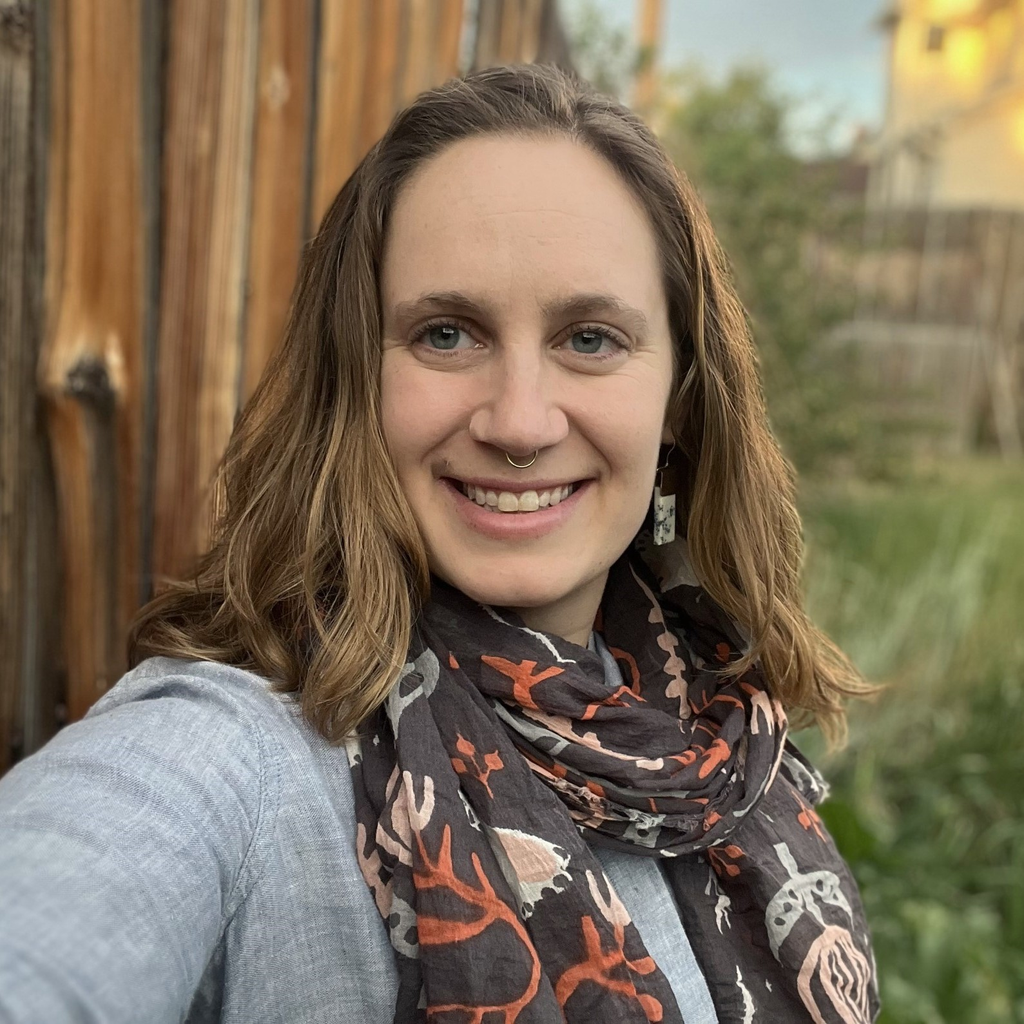

Some of my past experiences include:

- A post-doc with the USDA Northern Plains Climate Hub, 2024-2025
- A PhD in soil science from the University of Wyoming, 2020-2024
- Farming and teaching English in Nepal as a Fulbright Scholar, 2019
- Studying perennial grains as an intern at The Land Institute, 2018
- A Bachelors in biology and neuroscience from Oberlin College, 2014-2018